# Exploring Honey production Data

Abel Takele & Meron Zeru

# Introduction

According to the National Agricultural Statistics Service(NASS) analysis, In 2006, Decline in the number of honeybee was a major concern which is a major component to American honey agriculture.

> Large numbers of hives were lost to Colony Collapse Disorder, a phenomenon of disappearing worker bees causing the remaining hive colony to collapse.

Speculation to the cause of this disorder points to hive diseases and pesticides harming the pollinators, though no overall consensus has been reached. After twelve years, some industries are observing recovery but the American honey industry is still largely struggling. The U.S. used to locally produce over half the honey it consumes per year. Now, honey mostly comes from overseas, with 350 of the 400 million pounds of honey consumed every year originating from imports. This toutorial provides insight into honey production supply and demand in America by state by analyzing the data from NASS, reporting body for the US Department of Agriculture (USDA) between the years 1998 to 2012.

While learing techniques to work with a dataset using R, it is always a best practice to have questions to initiate the motive of our analysis. For examaple we start by trying to answer the following questions.

- How has honey production yield changed from 1998 to 2012?
- Over time, which states produce the most honey? Which produce the least? Which have experienced the most change in honey yield?
- Are there any patterns that can be observed between total honey production and value of production every year? How has value of production, which in some sense could be tied to demand, changed every year?

# Data Curation

- The following section demonstrates the steps taken to clean and prepare the honeyproduction dataset. Raw .csv files can be found on this page https://www.nass.usda.gov/About_NASS/index.php

The following code chunck will produce 3 datasets with the same type of information on honeybee production and prices. The datasets are for each year interval (1998-2002, 2003-2007, 2008-2012). We will use the read_lines() fuction, becuase the data is messy.

We start by importing the libraries we need to perform the taskes, I personally prefer to keep all the imported libraries together, because it will make the aesthetics look inviting to read than having them in different code chunks.

```r
library(tidyverse)
library(ggplot2)
library(dplyr)
library(tidyr)
library(readr)
library(stringr)
library(data.table)
library(formattable)
```

```r
options(warn = -1) #avoiding unnecessary warrning messages
honeyraw9802 <- read_lines("C:/Users/Abel/Desktop/honeyraw_1998to2002.csv")
honeyraw9802 <- data.frame(honeyraw9802[-1:-4])
str(honeyraw9802)
```

```
## 'data.frame':    293 obs. of  1 variable:
##  $ honeyraw9802..1..4.: Factor w/ 284 levels "1,\"c\",\"\"",..: 52 53 51 50 54 4 6 5 7 8 ...
```

```r
honeyraw0307 <- read_lines("C:/Users/Abel/Desktop/honeyraw_2003to2007.csv")
honeyraw0307 <- data.frame(honeyraw0307[-1:-76])
str(honeyraw0307)
```

```
## 'data.frame':    319 obs. of  1 variable:
##  $ honeyraw0307..1..76.: Factor w/ 310 levels "1,\"c\",\"\"",..: 60 61 59 58 62 4 6 5 7 8 ...
```

```r
honeyraw0812 <- read_lines("C:/Users/Abel/Desktop/honeyraw_2008to2012.csv")
honeyraw0812 <- data.frame(honeyraw0812[-1:-67])
str(honeyraw0812) #structure of our data frame
```

```
## 'data.frame':    317 obs. of  1 variable:
##  $ honeyraw0812..1..67.: Factor w/ 293 levels "1,\"c\",\"\"",..: 55 56 54 53 57 3 4 5 6 7 ...
```

Combine the 3 datasets into a list, then loop through each dataset by index to perform cleaning. At the end of the loop, each cleaned dataframe is saved into a list of 3 clean data frames.

```r
honeyrawlist <- list(honeyraw9802,honeyraw0307,honeyraw0812)
honeyfinallist <- list()
for(honey_idx in 1:length(honeyrawlist)) {
  honey <- honeyrawlist[[honey_idx]]
  honey <- honey %>%
# Each dataframe is still csv formatted. Use separate() to split column
# into multiple ones by comma. Set variable names and remove irrelevant columns.
    separate(colnames(honey[1]), paste0("X", 1:9), sep = ",") %>%
    setNames(c("X1", "X2", "state", "numcol", "yieldpercol","totalprod",
               "stocks","priceperlb","prodvalue")) %>%
    select(-X1, -X2)
# Glimpse shows that variables are considered characters. Convert each
# variable to the correct class. Numbers are manipulated to remove the
# scales (ex. number of colonies is in 1,000s). Remove double quotes
# from state abbreviations in state column.
  honey$state <- gsub("\"", "", honey$state)
  honey$numcol <- as.integer(honey$numcol)*1000
  honey$yieldpercol <- as.integer(honey$yieldpercol)
  honey$totalprod <- as.integer(honey$totalprod)*1000
  honey$stocks <- as.integer(honey$stocks)*1000
  honey$priceperlb <- currency(as.numeric(honey$priceperlb))/100
  honey$prodvalue <- currency(as.numeric(honey$prodvalue))*1000
  honey <- honey %>%
# Remove irrelevant rows by using filter() to select rows to keep.
# These are rows that don't have NA values in prodvalue column and
# rows that don't have forward slashes in state column.
    filter(!is.na(prodvalue)&!grepl("/", honey$state))
  honeyfinallist[[honey_idx]] <- honey

honeyfinaldf <- bind_rows(honeyfinallist)
glimpse(honeyfinaldf)  #almost clean data frame
}
```

```
## Observations: 217
## Variables: 7
## $ state       <chr> "AL", "AZ", "AR", "CA", "CO", "FL", "GA", "HI", "I...
## $ numcol      <dbl> 16000, 55000, 53000, 450000, 27000, 230000, 75000,...
## $ yieldpercol <int> 71, 60, 65, 83, 72, 98, 56, 118, 50, 71, 92, 78, 4...
## $ totalprod   <dbl> 1136000, 3300000, 3445000, 37350000, 1944000, 2254...
## $ stocks      <dbl> 159000, 1485000, 1688000, 12326000, 1594000, 45080...
## $ priceperlb  <dbl> 0.72, 0.64, 0.59, 0.62, 0.70, 0.64, 0.69, 0.77, 0....
## $ prodvalue   <dbl> 818000, 2112000, 2033000, 23157000, 1361000, 14426...
## Observations: 425
## Variables: 7
## $ state       <chr> "AL", "AZ", "AR", "CA", "CO", "FL", "GA", "HI", "I...
## $ numcol      <dbl> 16000, 55000, 53000, 450000, 27000, 230000, 75000,...
## $ yieldpercol <int> 71, 60, 65, 83, 72, 98, 56, 118, 50, 71, 92, 78, 4...
## $ totalprod   <dbl> 1136000, 3300000, 3445000, 37350000, 1944000, 2254...
## $ stocks      <dbl> 159000, 1485000, 1688000, 12326000, 1594000, 45080...
## $ priceperlb  <dbl> 0.72, 0.64, 0.59, 0.62, 0.70, 0.64, 0.69, 0.77, 0....
## $ prodvalue   <dbl> 818000, 2112000, 2033000, 23157000, 1361000, 14426...
## Observations: 626
## Variables: 7
## $ state       <chr> "AL", "AZ", "AR", "CA", "CO", "FL", "GA", "HI", "I...
## $ numcol      <dbl> 16000, 55000, 53000, 450000, 27000, 230000, 75000,...
## $ yieldpercol <int> 71, 60, 65, 83, 72, 98, 56, 118, 50, 71, 92, 78, 4...
## $ totalprod   <dbl> 1136000, 3300000, 3445000, 37350000, 1944000, 2254...
## $ stocks      <dbl> 159000, 1485000, 1688000, 12326000, 1594000, 45080...
## $ priceperlb  <dbl> 0.72, 0.64, 0.59, 0.62, 0.70, 0.64, 0.69, 0.77, 0....
## $ prodvalue   <dbl> 818000, 2112000, 2033000, 23157000, 1361000, 14426...
```

### Attributes of the final data frame

- numcol: Number of honey producing colonies. Honey producing colonies are the maximum number of colonies from which honey was taken during the year. It is possible to take honey from colonies which did not survive the entire year
- yieldpercol: Honey yield per colony. Unit is pounds
- totalprod: Total production (numcol x yieldpercol). Unit is pounds
- stocks: Refers to stocks held by producers. Unit is pounds
- priceperlb: Refers to average price per pound based on expanded sales. Unit is dollars.
- prodvalue: Value of production (totalprod x priceperlb). Unit is dollars.

```r
# some state names are in full length instead of abbreviations like the other ones.
#Use match() to find full state names and replace with abbreviations.
matches_and_nas <- match(honeyfinaldf$state, state.name)
matches <- !is.na(matches_and_nas)
honeyfinaldf$state[matches] <- state.abb[matches_and_nas[matches]]

# Lastly, we want to add a year column to represent which year each value
# belongs to. Data for different years are stored in contiguous blocks and
# states are listed in alphabetical order. Each year begins with state AL
# and ends with state WY. Thus, when states rotate back from WY to AL we
# know the data is for a new year. Knowing this, we can use rep() to append
# year information to each row.
ystart <- c(grep("AL", honeyfinaldf$state))
yend <- c(grep("WY", honeyfinaldf$state))
years <- 1998:2012
ynums <- yend - ystart + 1
honeyfinaldf$year <- rep(years, ynums)

head(honeyfinaldf,20)  #Ready for analysis data frame(tidy data)
```

```
##    state numcol yieldpercol totalprod   stocks priceperlb prodvalue year
## 1     AL  16000          71   1136000   159000       0.72    818000 1998
## 2     AZ  55000          60   3300000  1485000       0.64   2112000 1998
## 3     AR  53000          65   3445000  1688000       0.59   2033000 1998
## 4     CA 450000          83  37350000 12326000       0.62  23157000 1998
## 5     CO  27000          72   1944000  1594000       0.70   1361000 1998
## 6     FL 230000          98  22540000  4508000       0.64  14426000 1998
## 7     GA  75000          56   4200000   307000       0.69   2898000 1998
## 8     HI   8000         118    944000    66000       0.77    727000 1998
## 9     ID 120000          50   6000000  2220000       0.65   3900000 1998
## 10    IL   9000          71    639000   204000       1.19    760000 1998
## 11    IN   9000          92    828000   489000       0.85    704000 1998
## 12    IA  50000          78   3900000  2301000       0.70   2730000 1998
## 13    KS  16000          46    736000   390000       0.87    640000 1998
## 14    KY   3000          50    150000    51000       1.40    210000 1998
## 15    LA  41000         111   4551000   865000       0.59   2685000 1998
## 16    ME  10000          26    260000   117000       0.69    179000 1998
## 17    MD   7000          44    308000    92000       1.10    339000 1998
## 18    MI  80000          85   6800000  3672000       0.66   4488000 1998
## 19    MN 140000          79  11060000  2765000       0.65   7189000 1998
## 20    MS  18000          86   1548000   898000       0.58    898000 1998
```

# Distribution Analysis

In this section of the data science processes, we will try to acess how well or how badly is our data distributed throughout time. We will try to analayze and find the best distribution that fits our data. Before jumping into all the cool R codes that prepares graphs, it’s a good start to start defining what distribution of data is.

What is distribution ?

The distribution of a statistical data set (or a population) is a listing or function showing all the possible values (or intervals) of the data and how often they occur. When a distribution of categorical data is organized, you see the number or percentage of individuals in each group. When a distribution of numerical data is organized, they’re often ordered from smallest to largest, broken into reasonably sized groups (if appropriate), and then put into graphs and charts to examine the shape, center, and amount of variability in the data.

For more Reading on Distribtion Analysis

http://www.dummies.com/education/math/statistics/what-the-distribution-tells-you-about-a-statistical-data-set/

It is alway a good idea to start with a scatter plot, to observe some behaviors of the data.

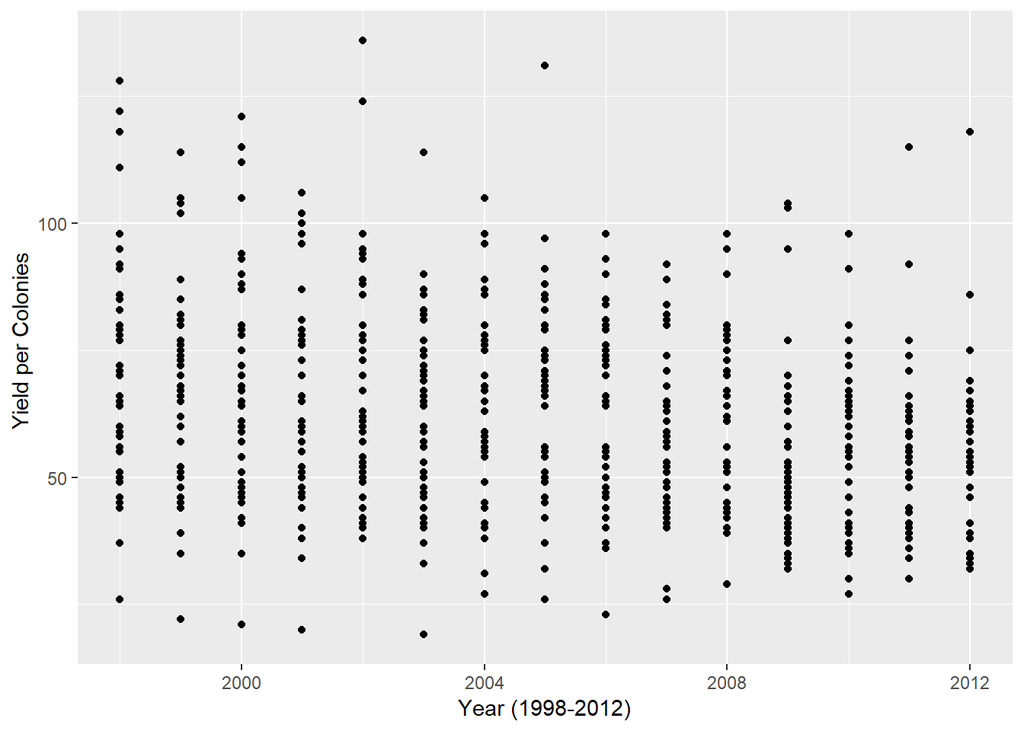

```r
honeyfinaldf %>%
  ggplot(aes(x = as.numeric(year), y = yieldpercol)) +
   geom_point()+
    labs(y="Yield per Colonies ", x = "Year (1998-2012)")
```

The plot dosen’t get us what we wanted, so let’t try a boxplot grouped by year.

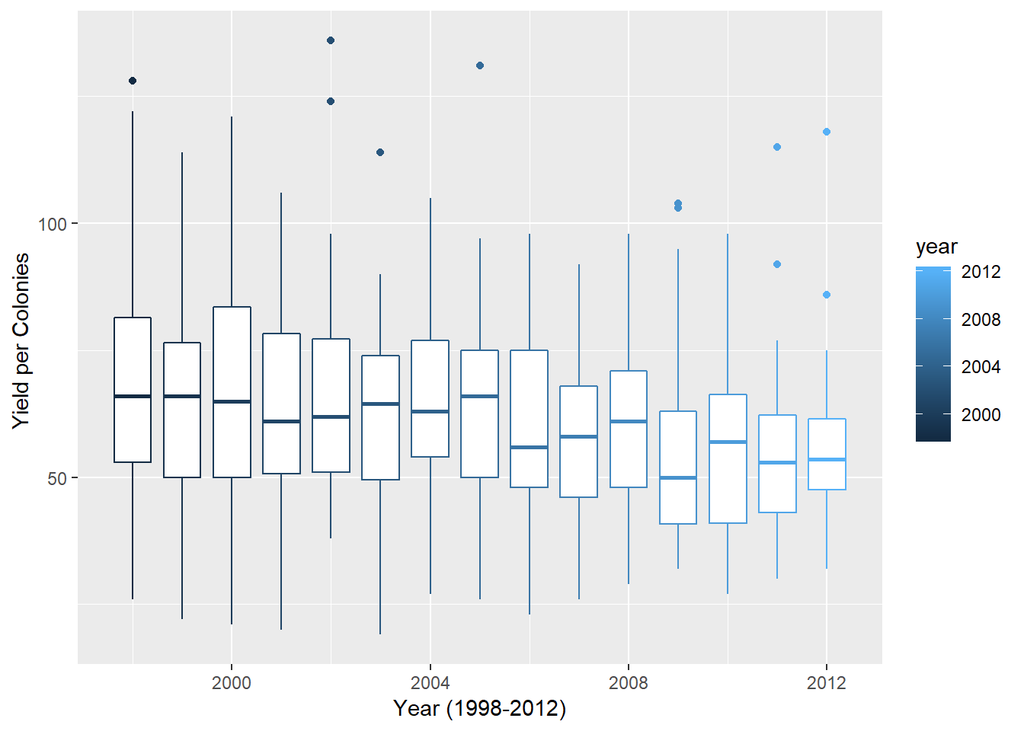

```r
honeyfinaldf %>%
  ggplot(aes(x = year, y = yieldpercol, group = year)) +
    geom_boxplot(aes(color=year)) +
    labs(y="Yield per Colonies ", x = "Year (1998-2012)")
```

Let us now see how the price was changing through the given period

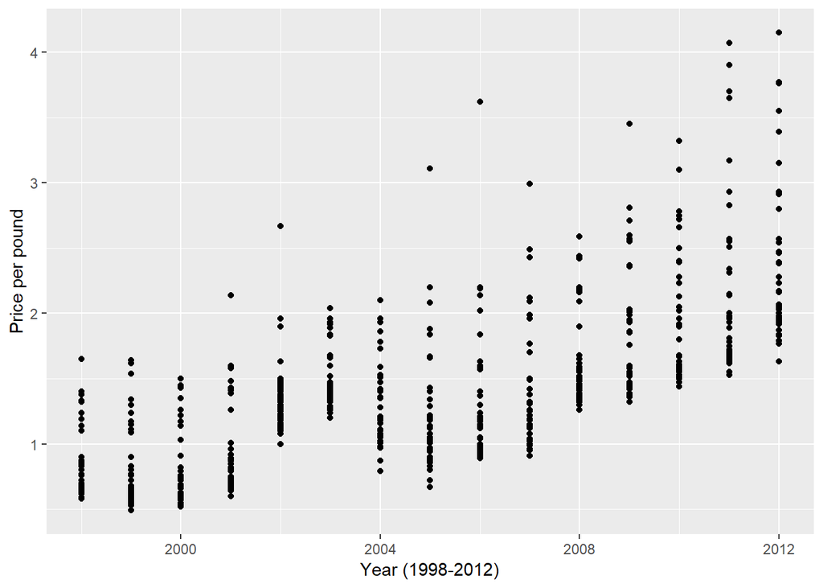

```r
honeyfinaldf %>%
  ggplot(aes(x = as.numeric(year), y = priceperlb)) +
   geom_point()+
    labs(y="Price per pound", x = "Year (1998-2012)")
```

## Correlation and analysis.

In this section we are trying to find relationships between the attributes, wich can lead us to pridiction based off of some factors.

Let’s explore! Let’s see how the total production and price of honey in the US has been changing over time.

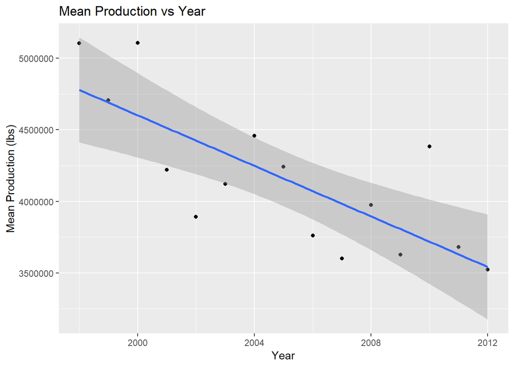

```r
honeyfinaldf$prodvalue <- honeyfinaldf$totalprod *honeyfinaldf$priceperlb #fixing the round off error

mean_prod <- length(unique(honeyfinaldf$year))
for(i in unique(honeyfinaldf$year)) {
  mean_prod[i - unique(honeyfinaldf$year)[1] + 1] <- mean(honeyfinaldf[honeyfinaldf$year == i,]$totalprod)
}

qplot(x = unique(honeyfinaldf$year), y = mean_prod, xlab = "Year", ylab = "Mean Production (lbs)", main ="Mean Production vs Year") +
  geom_smooth(method = "lm")
```

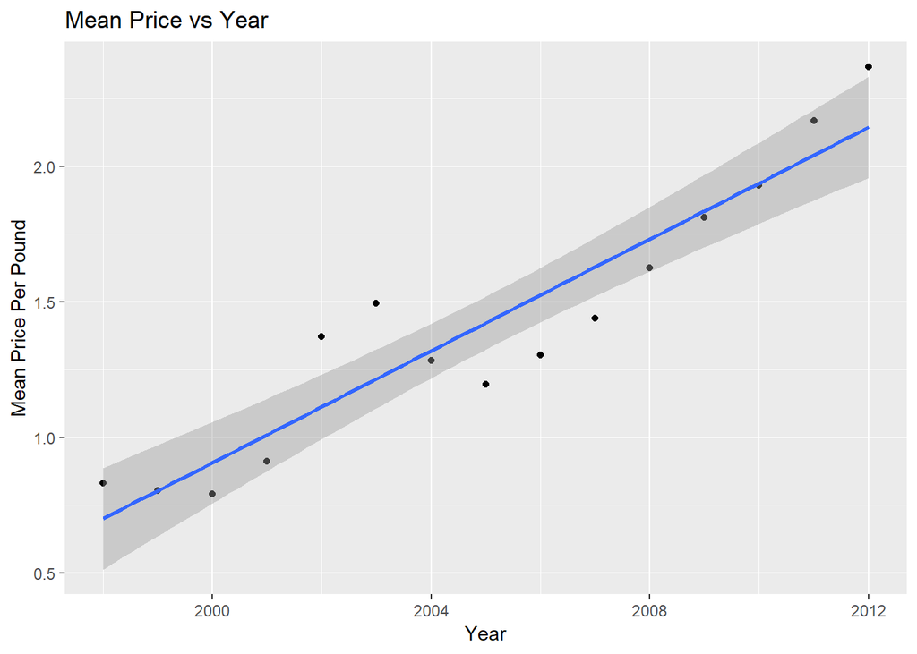

```r
mean_pric <- length(unique(honey$year))
for(i in unique(honeyfinaldf$year)) {
  mean_pric[i - unique(honeyfinaldf$year)[1] + 1] <- mean(honeyfinaldf[honeyfinaldf$year == i,]$priceperlb)
}
qplot(x = unique(honeyfinaldf$year), y = mean_pric, xlab = "Year", ylab = "Mean Price Per Pound", main ="Mean Price vs Year") +
  geom_smooth(method = "lm")
```

So far we know about the price and production changes through the given period of time, now lets see how heach state did on production and price in the year of 2012.

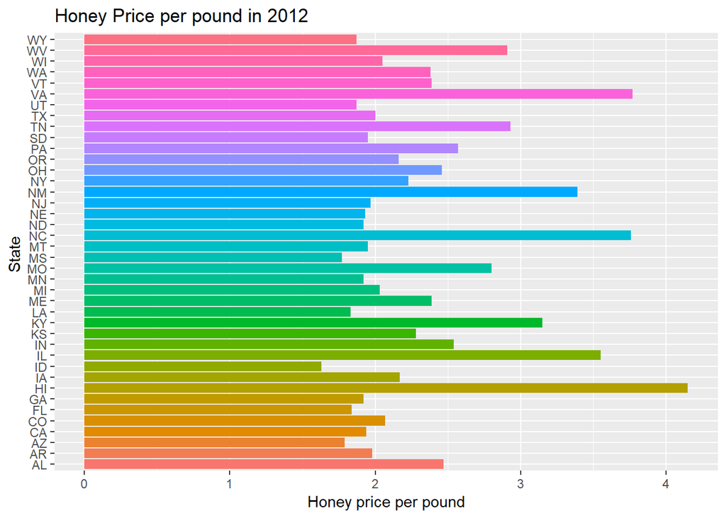

```r
ggplot(data = honeyfinaldf[honeyfinaldf$year == 2012,], mapping = aes(x = state, y = priceperlb, fill = state)) +
  geom_bar(stat = "identity") +
  guides(fill = FALSE) +
  xlab("State ") +
  ylab("Honey price per pound") +
  ggtitle("Honey Price per pound in 2012") +
  coord_flip()
```

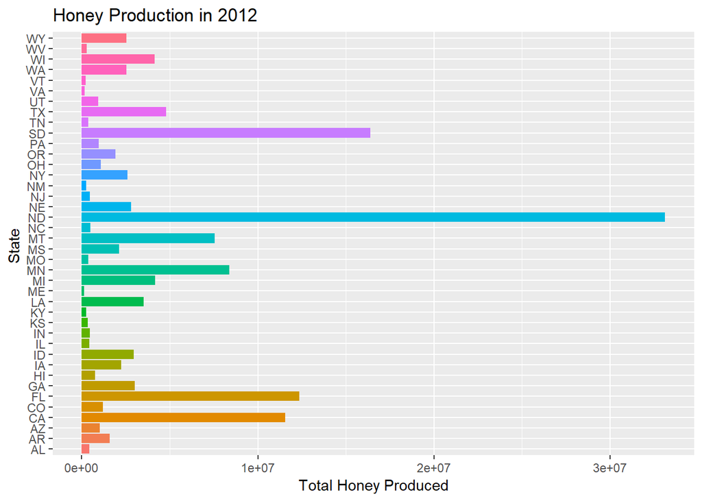

```r
ggplot(data = honeyfinaldf[honeyfinaldf$year == 2012,], mapping = aes(x = state, y = totalprod, fill = state)) +
  geom_bar(stat = "identity") +
  guides(fill = FALSE) +
  xlab("State ") +
  ylab("Total Honey Produced") +
  ggtitle("Honey Production in 2012") +
  coord_flip()
```

## Regression analysis

Linear regression is a linear approach to modelling the relationship between a scalar response (or dependent variable) and one or more explanatory variables (or independent variables). The case of one explanatory variable is called simple linear regression. For more than one explanatory variable, the process is called multiple linear regression.

We will now try to see if there is a relationship between a scalar responses to fit a regression model.

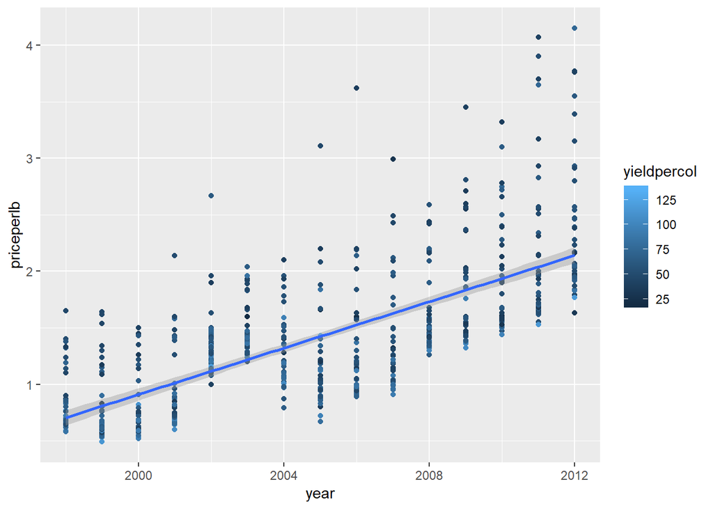

```r
honeyfinaldf %>%
  ggplot(aes(x=year,y=priceperlb, color=yieldpercol))+
  geom_point()+
  geom_smooth(method = lm)
```

Since the regression line is linear, which is an indicator of a relationship between price per pound of honey, the time(years), and the yield per colony; we will use yieldpercol and year to pridict(regress) the price.

```r
modelprice <- lm(formula = priceperlb ~ year * yieldpercol,data = honeyfinaldf)
broom::tidy(modelprice)
```

```
## # A tibble: 4 x 5
##   term                estimate std.error statistic  p.value
##   <chr>                  <dbl>     <dbl>     <dbl>    <dbl>
## 1 (Intercept)      -243.       27.3          -8.89 6.33e-18
## 2 year                0.122     0.0136        8.96 3.71e-18
## 3 yieldpercol         0.875     0.429         2.04 4.20e- 2
## 4 year:yieldpercol   -0.000440  0.000214     -2.05 4.04e- 2
```

$$X_1 \rightarrow year\\
X_2 \rightarrow yieldpercol \\
X_3 \rightarrow year:yieldpercol\\
y \rightarrow price per pound$$

## Conclusion and Aknowledgment

### Aknowledgement

This tutorial is based off of but not limited to the notes and codes from the course Introduction to Data Science in the University of Maryland College Park(Spring2019).